# Portafolio de Proyectos 1

# 5 Excepciones

• Las excepciones son eventos que representan situaciones excepcionales. • Alteran el flujo de ejecución convencional. • Python lanza excepciones automáticamente cuando se producen errores. • El programador puede lanzar excepciones de manera explícita y también capturar excepciones para actuar como se crea conveniente.

### Try/except

• Permite capturar excepciones y actuar en consecuencia.

Ejemplo: error de acceso fuera de rango.

```python
# lista = [6, 1, 0, 5]
# lista[4]
# print('Código tras el error')
```

```python
# lista = [6, 1, 0, 5]
# i = 300
# try:
#     a = lista[i]
# except IndexError:
#     print('He capturado la excepción de tipo IndexError')
#     a = 0
# print('Código tras el bloque try')
# print(a)
```

• Normalmente, al capturar excepciones, querremos ser lo más específicos posible, pero también se puedes usar una sentencia try-except que capture cualquier error.

```python
# try:
#     4/0
# except:
#     print('He capturado la división por cero')
```

• Recoger la excepción e imprimir el mensaje de error

```python
# lista = [6, 1, 0, 5]
# try:
#     print(lista[4])
# except Exception as e:
#     print("Error = " + str(e))
# print('Reacheable Code')
```

### Try/finally

• A través de finally podemos especificar código que queremos que se ejecute siempre (independientemente de si se produce la excepción o no). • Se suele usar para liberar recursos.

```python
# lista = [6, 1, 0, 5]
# try:
#     a = lista[1]
# except IndexError:
#     print('Exception IndexError Captured')
# finally:
#     print('Bloque finally')
# b = lista[2]
# print('Código tras el bloque try')
# print(b)
```

### raise

• La sentencia raise nos permite lanzar excepciones de manera explícita.

```python
# lista = [6, 1, 0, 5]
# indice = 4
# try:
#     if indice >= len(lista):
#         raise IndexError('Índice fuera de rango')
# except IndexError:
#     print('Excepción de tipo IndexError capturada')
```

## 5.1 Ejercicios

1. Escribe un programa que calcule la suma de todos los elementos de una lista dada. La lista sólo puede contener elementos numéricos.
2. Dada una lista con elementos duplicados, escribir un programa que muestre una nueva lista con el mismo contenido que la primera pero sin elementos duplicados. Para este ejercicio, no puedes hacer uso de objetos de tipo 'Set'.
3. Escribe un programa que construya un diccionario que contenga un número (entre 1 y n) de elementos de esta forma: (x, x*x). Ejemplo: para n = 5, el diccionario resultante sería {1: 1, 2: 4, 3: 9, 4: 16, 5: 25}
4. Escribe un programa que, dada una lista de palabras, compruebe si alguna empieza por 'a' y tiene más de 9 caracteres. Si dicha palabra existe, el programa deberá terminar en el momento exacto de encontrarla. El programa también debe mostrar un mensaje apropiado por pantalla que indique el éxito o el fracaso de la búsqueda. En caso de éxito, también se mostrará por pantalla la palabra encontrada.
5. Dada una lista L de números positivos, escribir un programa que muestre otra lista (ordenada) que contenga todo índice i que cumpla la siguiente condición: L[i] es múltiplo de 3. Por ejemplo, dada la lista L = [3,5,13,12,1,9] el programa mostrará la lista [0,3,5] dado que L[0], L[3] y L[5] son, respectivamente, 3, 12 y 9, que son los únicos múltiplos de 3 que hay en L.
6. Dado un diccionario cuyos elementos son pares de tipo string y numérico (es decir, las claves son de tipo 'str' y los valores son de tipo 'int' o 'float'), escribe un programa que muestre por pantalla la clave cuyo valor asociado representa el valor númerico más alto de todo el diccionario. Por ejemplo, para el diccionario {'a': 4.3, 'b': 1, 'c': 7.8, 'd': -5} la respuesta sería 'c', dado que 7.8 es el valor más alto de los números 4.3, 1, 7.8 y -5.
7. Dada la lista a = [2, 4, 6, 8] y la lista b = [7, 11, 15, 22], escribe un programa que itere las listas a y b y multiplique cada elemento de a que sea mayor que 5 por cada elemento de b que sea menor que 14. El programa debe mostrar los resultados por pantalla.
8. Escribir un programa que pida un valor numérico X al usuario. Para ello podéis hacer uso de la función predefinida 'input'. El programa deberá mostrar por pantalla el resultado de la división 10/X. En caso de que el usuario introduzca valores no apropiados, el programa deberá gestionar correctamente las excepciones, por ejemplo, mostrando mensajes informativos por pantalla.
9. Escribir un programa que cree un diccionario cualquiera. Posteriormente, el programa pedirá al usuario (a través de la función predefinida 'input') que introduzca una clave del diccionario. Si la clave introducida es correcta (es decir, existe en el diccionario), el programa mostrará por pantalla el valor asociado a dicha clave. En caso de que la clave no exista, el programa gestionará de manera apropiada el error, por ejemplo, mostrando un mensaje informativo al usuario.
10. Escribe una list comprehension que construya una lista con los números enteros positivos de una lista de números dada. La lista original puede incluir números de tipo float, los cuales deben ser descartados.
11. Escribe una set comprehension que, dada una palabra, construya un conjunto que contenga las vocales de dicha palabra.
12. Escribe una list comprehension que construya una lista con todos los números del 0 al 50 que contengan el dígito 3. El resultado será: [3, 13, 23, 30, 31, 32, 33, 34, 35, 36, 37, 38, 39, 43].
13. Escribe una dictionary comprehension que construya un diccionario que incluya los tamaños de cada palabra en una frase dada. Ejemplo: el resultado para la frase "Soy un ser humano" será {'Soy': 3, 'un': 2, 'ser': 3, 'humano': 6}
14. Escribe una list comprehension que construya una lista que incluya todos los números del 1 al 10 en orden. La primera mitad se mostrarán en formato numérico; la segunda mitad en texto. Es decir, el resultado será: [1, 2, 3, 4, 5, 'seis', 'siete', 'ocho', 'nueve', 'diez'].

# 6 Soluciones

```python
# Ejercicio 1: sumar todos los elementos de una lista numérica
numeros = [1, 5, 9, 2, 3]  # Lista de números a sumar
suma = 0  # Acumulador inicializado en cero
for numero in numeros:  # Recorre cada elemento de la lista
    suma += numero  # Suma el elemento actual al acumulador
print(suma)  # Muestra el total: 20
```

```
20
```

```python
# Ejercicio 2: eliminar duplicados preservando el orden de aparición
numeros = [1, 2, 2, 3, 4, 5, 4, 5, 3, 3, 1]  # Lista con elementos repetidos
resultado = []  # Lista vacía para guardar valores únicos
for numero in numeros:  # Recorre cada número de la lista original
    if numero not in resultado:  # Solo añade si aún no está en resultado
        resultado.append(numero)  # Añade el número por primera vez
print(resultado)  # Muestra [1, 2, 3, 4, 5] sin duplicados
```

```
[1, 2, 3, 4, 5]
```

```python
# Ejercicio 3: diccionario {n: n²} para n desde 1 hasta n dado
n = 5  # Límite superior del rango
diccionario = {}  # Diccionario vacío que iremos rellenando
for i in range(1, n + 1):  # Recorre los enteros del 1 al 5 inclusive
    diccionario[i] = i * i  # Asocia cada clave i con su cuadrado i²
print(diccionario)  # Muestra {1: 1, 2: 4, 3: 9, 4: 16, 5: 25}
```

```
{1: 1, 2: 4, 3: 9, 4: 16, 5: 25}
```

```python
# Ejercicio 4
palabras = ["", "Valencia", "python", "asignaturas", "programación", "java", "estudiantes", "académicos"]
# Bucle for: itera con 'palabra in palabras' en cada vuelta
for palabra in palabras:
    # if: ejecuta el bloque indentado solo cuando len(palabra) >= 9 and palabra[0] == 'a'
    if len(palabra) >= 9 and palabra[0] == 'a':
        # Muestra mensaje formateado en consola: f"Palabra encontrada: {palabra}"
        print(f"Palabra encontrada: {palabra}")
        # break: detiene el bucle en cuanto se encuentra el resultado buscado
        break
# else: bloque que se ejecuta si ninguna condición previa fue verdadera
else:
    # Imprime el texto o etiqueta: "Palabra no encontrada"
    print("Palabra no encontrada")
```

```
Palabra encontrada: asignaturas
```

```python
# Ejercicio 5: índices donde L[i] es múltiplo de 3
L = [3, 5, 13, 12, 1, 9]  # Lista de números positivos
resultado = []  # Lista para guardar los índices que cumplen la condición
for i in range(len(L)):  # Recorre cada posición i de la lista
    if L[i] % 3 == 0:  # Comprueba si el valor en posición i es múltiplo de 3
        resultado.append(i)  # Guarda el índice i en la lista resultado
print(resultado)  # Muestra [0, 3, 5] porque L[0]=3, L[3]=12, L[5]=9
```

```
[0, 3, 5]
```

```python
# Ejercicio 6
d = {'a':4.3, 'b':1, 'c':7.8, 'd':-5}
# Evalúa la expresión de la derecha y guarda el resultado en 'maximo'
maximo = float("-inf") # Inicializamos la variable 'maximo' a -infinito. Para este ejercicio, también valdría cualquier valor negativo muy pequeño.
# Obtenemos la longitud/cantidad de elementos
if(len(d) == 0):
    # Imprime el texto o etiqueta: "El diccionario está vacío"
    print("El diccionario está vacío")
# Bucle for: itera con 'clave, valor in d.items()' en cada vuelta
for clave, valor in d.items():
    # if: ejecuta el bloque indentado solo cuando valor > maximo
    if valor > maximo:
        # Evalúa la expresión de la derecha y guarda el resultado en 'maximo'
        maximo = valor
        # Evalúa la expresión de la derecha y guarda el resultado en 'resultado'
        resultado = clave
# Muestra en consola el contenido de resultado
print(resultado)
```

```
c
```

```python
# Ejercicio 7
a = [2, 4, 6, 8]
# Evalúa la expresión de la derecha y guarda el resultado en 'b'
b = [7, 11, 15, 22]
# Bucle for: itera con 'i in a' en cada vuelta
for i in a:
    # if: ejecuta el bloque indentado solo cuando i > 5
    if i > 5:
        # Bucle for: itera con 'j in b' en cada vuelta
        for j in b:
            # if: ejecuta el bloque indentado solo cuando j < 14
            if j < 14:
                # Muestra mensaje formateado en consola: f"{i} x {j} = {i*j}"
                print(f"{i} x {j} = {i*j}")
```

```
6 x 7 = 42
6 x 11 = 66
8 x 7 = 56
8 x 11 = 88
```

```python
# Ejercicio 8
try:
    # Evalúa la expresión de la derecha y guarda el resultado en 'x'
    x = input()
    # Evalúa la expresión de la derecha y guarda el resultado en 'numero'
    numero = float(x)
    # Muestra mensaje formateado en consola: f"El resultado de 10/{x} es: {10/numero}"
    print(f"El resultado de 10/{x} es: {10/numero}")
# Capturamos y manejamos el error
except ValueError:
    # Muestra mensaje formateado en consola: f"El valor '{x}' no es numérico"
    print(f"El valor '{x}' no es numérico")
# Capturamos y manejamos el error
except ZeroDivisionError:
    # Imprime el texto o etiqueta: "Error: división por cero"
    print("Error: división por cero")
```

```
 8
```

```
El resultado de 10/8 es: 1.25
```

```python
# Ejercicio 9
notas = {'Programación': 9.5, "Inteligencia artificial": 7.6, "Redes": 5.2, "Sistemas operativos": 6.4}
# Intentamos ejecutar código que puede fallar
try:
    # Evalúa la expresión de la derecha y guarda el resultado en 'asignatura'
    asignatura = input("Introduce una asignatura")
    # Muestra mensaje formateado en consola: f"La nota de la asignatura '{asignatura}' es: {notas[asignatura]}"
    print(f"La nota de la asignatura '{asignatura}' es: {notas[asignatura]}")
# Capturamos y manejamos el error
except KeyError:
    # Muestra mensaje formateado en consola: f"Asignatura incorrecta: {asignatura}"
    print(f"Asignatura incorrecta: {asignatura}")
```

```
Introduce una asignatura Programación
```

```
La nota de la asignatura 'Programación' es: 9.5
```

```python
# Ejercicio 10
lista = [1, 4, -3, -1.5, 6.5, 2, 8, 2.1]
# Consultamos el tipo de dato del objeto
[numero for numero in lista if type(numero) == int and numero > 0]
```

```
[1, 4, 2, 8]
```

```python
# Ejercicio 11: set comprehension con las vocales presentes en la palabra
palabra = 'murcielago'  # Palabra que contiene las cinco vocales
{letra for letra in palabra if letra in ('a', 'e', 'i', 'o', 'u')}  # Conjunto de vocales únicas
```

```
{'a', 'e', 'i', 'o', 'u'}
```

```python
# Ejercicio 12
[numero for numero in range(51) if '3' in str(numero)]
```

```
[3, 13, 23, 30, 31, 32, 33, 34, 35, 36, 37, 38, 39, 43]
```

```python
# Ejercicio 13
frase = "Soy un ser humano"
# Obtenemos la longitud/cantidad de elementos
{palabra : len(palabra) for palabra in frase.split() }
```

```
{'Soy': 3, 'un': 2, 'ser': 3, 'humano': 6}
```

```python
# Ejercicio 14
numero_a_palabra = {6 : "seis", 7 : "siete", 8 : "ocho", 9 : "nueve", 10 : "diez"}
# Comprehension: construye la colección aplicando una expresión a cada elemento iterable
[numero if numero <= 5 else numero_a_palabra[numero] for numero in range(1,11)]
```

```
[1, 2, 3, 4, 5, 'seis', 'siete', 'ocho', 'nueve', 'diez']
```

# Proyecto 6: numpy.ipynb

**Fecha de creación:** 06/07/2026  
**Título:** numpy

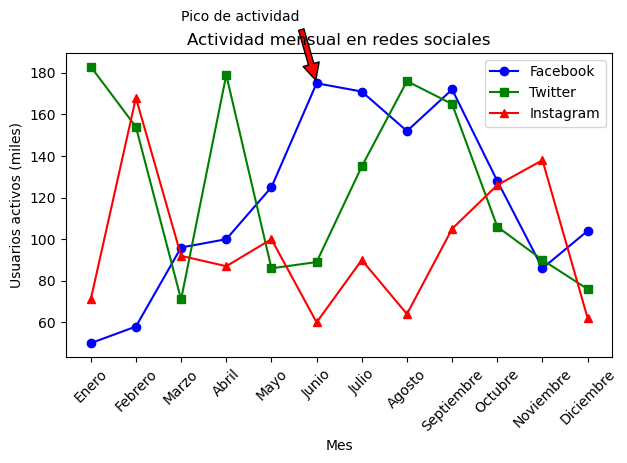

```python
# Your solution HERE !!!!
# Lista de meses de Enero a Diciembre eje X
meses = ['Enero', 'Febrero', 'Marzo', 'Abril', 'Mayo', 'Junio',
         'Julio', 'Agosto', 'Septiembre', 'Octubre', 'Noviembre', 'Diciembre']

# Tres series aleatorias de datos je Y una por red social
y0 = np.random.randint(50, 200, size=12)
y1 = np.random.randint(50, 200, size=12)
y2 = np.random.randint(50, 200, size=12)

# Creamos la figura y dibujamos las 3 líneas en el mismo gráfico
fig, ax = plt.subplots()
ax.plot(meses, y0, 'b-o', label='Facebook')
ax.plot(meses, y1, 'g-s', label='Twitter')
ax.plot(meses, y2, 'r-^', label='Instagram')

# Leyenda para identificar cada secuencia
ax.legend(loc='best')
# Título y nombres de ejes
ax.set_title('Actividad mensual en redes sociales')
ax.set_xlabel('Mes')
ax.set_ylabel('Usuarios activos (miles)')
# Rotamos etiquetas del eje X para que se lean mejor
plt.xticks(rotation=45)

# Anotación con texto y flecha en un punto del gráfico de Facebook
ax.annotate('Pico de actividad',
            xy=(meses[5], y0[5]),
            xytext=(meses[2], y0[5] + 30),
            arrowprops=dict(facecolor='red', shrink=0.05))

plt.tight_layout()
plt.show()
```

# Proyecto 7: Pandas.ipynb

**Fecha de creación:** 08/07/2026  
**Título:** PAO25_25_07_Python_Pandas

[figure not shown]

# PAO25_25_07_Python_Pandas

## 0.1 PAO 25-25 - Pandas

[figure not shown]

*Jesús Viera* https://github.com/Vierita23/machinelearning

# 1 Pandas

• Librería (de facto estándar) para estructurar datos tabulares • Multivariable (string, int, float, bool…) • Dos clases: – Series (1 dimensión) – DataFrames (2+ dimensiones)

```python
# Instalar pandas en el intérprete Python que ejecuta este notebook
import sys
# subprocess permite lanzar comandos del sistema (como pip) desde Python
import subprocess

# Ejecutamos pip install usando el mismo Python del kernel (evita instalar en otro entorno)
subprocess.run(
    # Lista de argumentos: python -m pip install pandas numpy en modo silencioso (-q)
    [sys.executable, "-m", "pip", "install", "pandas", "numpy", "-q"],
    # check=False: no lanza excepción si pip devuelve código de error
    check=False,
)

# Mostramos qué ejecutable de Python está usando el notebook
print("Python:", sys.executable)
```

```
Python: C:\Users\Jesus\anaconda3\envs\Machine2026\python.exe
```

```python
# Importamos Pandas con alias 'pd': librería estándar para tablas y series
import pandas as pd
# Importamos las clases Series (1D) y DataFrame (2D) directamente
from pandas import Series, DataFrame
# display renderiza DataFrames/Series con formato HTML en el notebook
from IPython.display import display
```

```python
# Consultamos la versión instalada de Pandas (útil para compatibilidad de API)
pd.__version__
```

```
'3.0.3'
```

# 2 Series

• Datos unidimensionales (similar a NumPy) • Elementos + índices modificables

```python
# Creamos una Serie: vector 1D con índice automático (0, 1, 2...)
countries = pd.Series(['Spain','Andorra','Gibraltar','Portugal','France'])
# Mostramos la Serie completa con índice y valores
print(countries)
```

```
0        Spain
1      Andorra
2    Gibraltar
3     Portugal
4       France
dtype: str
```

```python
# Creamos Serie con índice personalizado: las etiquetas no tienen que ser 0,1,2...
countries = pd.Series(['Spain','Andorra','Gibraltar','Portugal','France'],
                      # index=range(10,60,10) asigna etiquetas 10, 20, 30, 40, 50
                      index=range(10,60,10))
# Verificamos que cada país queda asociado a su etiqueta de índice
print(countries)
```

```
10        Spain
20      Andorra
30    Gibraltar
40     Portugal
50       France
dtype: str
```

```python
# Los índices pueden ser strings u otros tipos, no solo enteros
football_cities = pd.Series(['Barcelona','Madrid','Valencia','Sevilla'],
                            # Índices semánticos 'a','b','c','d' para acceso por etiqueta
                            index=['a','b','c','d'])
# Mostramos la Serie con índice de letras
print(football_cities)
```

```
a    Barcelona
b       Madrid
c     Valencia
d      Sevilla
dtype: str
```

```python
# Atributos de la Serie: nombre de la serie y nombre del índice
football_cities.name = 'Ciudades con dos equipos en primera' # nombrar la Serie
# index.name describe la columna de etiquetas (como cabecera del índice)
football_cities.index.name = 'Id' # Describir los índices
# Mostramos la Serie con metadatos de nombre aplicados
print(football_cities)
```

```
Id
a    Barcelona
b       Madrid
c     Valencia
d      Sevilla
Name: Ciudades con dos equipos en primera, dtype: str
```

```python
# Acceso por posición entera: iloc[2] devuelve el 3er elemento (índice 0-based)
print(football_cities.iloc[2])
# Acceso por etiqueta semántica: ['c'] busca el valor cuyo índice es 'c'
print(football_cities['c'])
# Comprobamos que ambos accesos devuelven el mismo valor (Valencia)
print(football_cities['c'] == football_cities.iloc[2])
```

```
Valencia
Valencia
True
```

# 3 Tratamiento similar a ndarray

```python
# Selección múltiple por etiquetas: devuelve sub-Serie con índices 'a' y 'c'
print(football_cities[ ['a','c'] ])
# Equivalente por posición: iloc[[0,3]] toma el 1er y 4to elemento
print(football_cities.iloc[[0, 3]])
```

```
Id
a    Barcelona
c     Valencia
Name: Ciudades con dos equipos en primera, dtype: str
Id
a    Barcelona
d      Sevilla
Name: Ciudades con dos equipos en primera, dtype: str
```

```python
# Slicing semántico: desde el inicio hasta 'c' (incluye ambos extremos)
print(football_cities[:'c']) # incluye ambos extremos con el indice semantico
# Slicing posicional: iloc[:2] toma posiciones 0 y 1 (excluye el 2)
print(football_cities.iloc[:2])
```

```
Id
a    Barcelona
b       Madrid
c     Valencia
Name: Ciudades con dos equipos en primera, dtype: str
Id
a    Barcelona
b       Madrid
Name: Ciudades con dos equipos en primera, dtype: str
```

```python
# Convertimos la sub-Serie a lista de Python (solo los valores)
lista = list(football_cities[:'c'])
# Mostramos la lista resultante ['Barcelona', 'Madrid', 'Valencia']
print(lista)
# Confirmamos que el tipo es list, no Series
print(type(lista))
```

```
['Barcelona', 'Madrid', 'Valencia']
<class 'list'>
```

```python
# Consultamos el tipo de dato del objeto
type(football_cities[:'c'])
```

```
pandas.Series
```

```python
# Convertimos la sub-Serie a ndarray de NumPy para operaciones vectoriales
import numpy as np
# np.array extrae los valores y los convierte en array NumPy
cities = np.array(football_cities[:'c'])
# Mostramos el array NumPy resultante
print(cities)
# Verificamos el tipo: ndarray permite operaciones matemáticas eficientes
print(type(cities))
```

```
['Barcelona' 'Madrid' 'Valencia']
<class 'numpy.ndarray'>
```

```python
# Convertimos la sub-Serie a diccionario {índice: valor}
lista = dict(football_cities[:'c'])
# Muestra pares clave-valor, ej: {'a': 'Barcelona', 'b': 'Madrid', ...}
print(lista)
```

```
{'a': 'Barcelona', 'b': 'Madrid', 'c': 'Valencia'}
```

```python
# Máscaras booleanas: filtrar elementos que cumplan una condición
fibonacci = pd.Series([0, 1, 1, 2, 3, 5, 8, 13, 21])
# Mostramos la Serie completa de Fibonacci
print(fibonacci)
# Creamos máscara: True donde el valor es mayor que 10
mask = fibonacci > 10
# La máscara es una Serie de booleanos alineada con el índice original
print(mask)
# Aplicamos la máscara: solo devuelve valores donde mask es True (13 y 21)
print(fibonacci[mask])
# Serie de comparación con los dos valores filtrados
dst = pd.Series([13,21])
# Mostramos la Serie de referencia para comparar
print(dst)
# equals() compara valores e índice: False porque dst tiene índice 0,1 y fibonacci 7,8
dst.equals(fibonacci)
# Extraemos los valores >10 y los guardamos en fb
fb = fibonacci[mask]
# reset_index(drop=True) renumera el índice a 0,1,... sin conservar el original
fb.reset_index(drop=True, inplace=True)
# Ahora fb tiene índice [0,1] con valores [13, 21]
print(fb)
# Tras reindexar, fb y dst tienen mismos valores e índice → True
dst.equals(fb)
```

```
0     0
1     1
2     1
3     2
4     3
5     5
6     8
7    13
8    21
dtype: int64
0    False
1    False
2    False
3    False
4    False
5    False
6    False
7     True
8     True
dtype: bool
7    13
8    21
dtype: int64
0    13
1    21
dtype: int64
0    13
1    21
dtype: int64
```

```
True
```

```python
# Las Series de Pandas son compatibles con funciones universales de NumPy
import numpy as np
# np.sum suma todos los elementos de la Serie (ignora NaN por defecto)
print(np.sum(fibonacci))
```

```
54
```

```python
# np.where reemplaza valores según condición: útil para imputar NaN
distances = pd.Series([12.1,np.nan,12.8,76.9,6.1,7.2])
# Si no es NaN → conserva el valor; si es NaN → sustituye por 2
valid_distances = np.where(pd.notnull(distances),distances,2)
# Resultado: array NumPy con NaN reemplazados por 2
print(valid_distances)
# np.where devuelve ndarray, no Series
print(type(valid_distances))
```

```
[12.1  2.  12.8 76.9  6.1  7.2]
<class 'numpy.ndarray'>
```

## 3.0.1 Iteración

```python
# Iteración 1: recorrer solo los valores de la Serie
for value in fibonacci:
    # Cada iteración imprime un término de la sucesión
    print('Value: ' + str(value))
# # iterar sobre indices
# Iteración 2: recorrer solo las etiquetas del índice
for index in fibonacci.index:
    # Cada iteración imprime una etiqueta de índice (0, 1, 2...)
    print('Index: ' + str(index))
```

```
Value: 0
Value: 1
Value: 1
Value: 2
Value: 3
Value: 5
Value: 8
Value: 13
Value: 21
Index: 0
Index: 1
Index: 2
Index: 3
Index: 4
Index: 5
Index: 6
Index: 7
Index: 8
```

```python
# items() devuelve pares (índice, valor) en cada iteración
for index, value in fibonacci.items():
    # Mostramos índice y valor juntos en cada línea
    print('Index: ' + str(index) + ' Value: ' + str(value))
```

```
Index: 0 Value: 0
Index: 1 Value: 1
Index: 2 Value: 1
Index: 3 Value: 2
Index: 4 Value: 3
Index: 5 Value: 5
Index: 6 Value: 8
Index: 7 Value: 13
Index: 8 Value: 21
```

```python
# zip() combina manualmente índice y valores (alternativa a items())
for index, value in zip(fibonacci.index, fibonacci):
    # Mismo resultado que items(): empareja etiqueta con su valor
    print('Index: ' + str(index) + ' Value: ' + str(value))
```

```
Index: 0 Value: 0
Index: 1 Value: 1
Index: 2 Value: 1
Index: 3 Value: 2
Index: 4 Value: 3
Index: 5 Value: 5
Index: 6 Value: 8
Index: 7 Value: 13
Index: 8 Value: 21
```

## 3.1 Series como diccionarios

• Interpretar el índice como clave • Acepta operaciones para diccionarios

```python
# Desde dict: las claves del diccionario se convierten en índice de la Serie
serie = pd.Series( { 'Carlos' : 100, 'Marcos': 98} )
# index contiene las claves: ['Carlos', 'Marcos']
print(serie.index)
# values contiene los valores numéricos: [100, 98]
print(serie.values)
# Mostramos la Serie completa con índice y valores
print(serie)
# Confirmamos que el objeto es una Series de Pandas
print(type(serie))
```

```
Index(['Carlos', 'Marcos'], dtype='str')
[100  98]
Carlos    100
Marcos     98
dtype: int64
<class 'pandas.Series'>
```

```python
# Las Series son mutables: podemos añadir, modificar y borrar por índice
serie['Pedro'] = 12
# Sobrescribimos el valor de 'Pedro' de 12 a 15 (misma clave, nuevo valor)
serie['Pedro']=15
# del elimina la entrada con índice 'Marcos' de la Serie
del serie['Marcos']
# Mostramos la Serie resultante: Carlos, Pedro (sin Marcos)
print(serie)
```

```
Carlos    100
Pedro      15
dtype: int64
```

```python
# Consulta condicional: verificar si una etiqueta existe antes de acceder
# print(serie['Marcos'])
if 'Marcos' in serie:
    # Solo se ejecuta si 'Marcos' sigue en el índice (aquí ya fue eliminado)
    print(serie['Marcos'])
# Mostramos el estado actual de la Serie tras las operaciones anteriores
print(serie)
```

```
Carlos    100
Pedro      15
dtype: int64
```

## 3.2 Operaciones entre series

```python
# Suma de Series: se alinean por índice, no por posición
# suma de valores con el mismo índice (NaN si no aparece en ambas)
serie1 = pd.Series([10,20,30,40], index=range(4) )
# serie2 solo tiene índices 0,1,2 → el índice 3 de serie1 quedará NaN
serie2 = pd.Series([1,2,3], index=range(3) )
# Suma elemento a elemento donde coinciden índices; NaN donde falta pareja
suma = serie1 + serie2
# Resultado: [11, 22, 33, NaN]
print(suma)
```

```
0    11.0
1    22.0
2    33.0
3     NaN
dtype: float64
```

```python
# resta de series (similar a la suma)
print(serie1 - serie2)
```

```
0     9.0
1    18.0
2    27.0
3     NaN
dtype: float64
```

```python
# Pre-filtrado: operar primero y luego reemplazar NaN resultantes
result = serie1 + serie2
# Detectamos valores nulos (NaN)
# isnull() crea máscara True donde hay NaN; asignamos 0 en esas posiciones
result[pd.isnull(result)] = 0 # mask con isnull()
# Ahora el índice 3 tiene 0 en lugar de NaN
print(result)
```

```
0    11.0
1    22.0
2    33.0
3     0.0
dtype: float64
```

### 3.2.1 Diferencias entre Pandas Series y diccionario

• Diccionario, es una estructura que relaciona las claves y los valores de forma arbitraria. • Series, estructura de forma estricta listas de valores con listas de índice asignado en la posición. • Series, es más eficiente para ciertas operaciones que los dicionarios. • En las Series los valores de entrada pueden ser listas o Numpy arrays. • En Series los índices semánticos pueden ser integers o caracteres, en los valores igual. • Series se podría entender entre una lista y un diccionario Python, pero es de una dimensión.

# 4 DataFrame

• Datos tabulares (filas x columnas) • Columnas: Series con índices compartidos

```python
# DataFrame desde dict: cada clave es una columna, cada lista una columna de datos
diccionario = { "Nombre" : ["Marisa","Laura","Manuel"],
                # Segunda clave del dict: columna 'Edad' con 3 valores enteros
                "Edad" : [34,29,12] }
# Mostramos la estructura del diccionario antes de convertirlo
print(diccionario)
# las claves identifican columnas
# pd.DataFrame convierte el dict en tabla 3 filas × 2 columnas
frame = pd.DataFrame(diccionario)
# Renderizamos la tabla en el notebook
display(frame)
```

```
{'Nombre': ['Marisa', 'Laura', 'Manuel'], 'Edad': [34, 29, 12]}
```

|  | Nombre | Edad |
| --- | --- | --- |
| 0 | Marisa | 34 |
| 1 | Laura | 29 |
| 2 | Manuel | 12 |

```python
# Mismo dict pero con índice de filas personalizado ['a','b','c']
diccionario = { "Nombre" : ["Marisa","Laura","Manuel"],
                # Columna 'Edad' paralela a 'Nombre' (misma longitud obligatoria)
                "Edad" : [34,29,12] }
# las claves identifican columnas
# index=['a','b','c'] etiqueta cada fila con letras en lugar de 0,1,2
frame = pd.DataFrame(diccionario, index = ['a', 'b', 'c'])
# Tabla con índice semántico visible en la primera columna
display(frame)
```

|  | Nombre | Edad |
| --- | --- | --- |
| a | Marisa | 34 |
| b | Laura | 29 |
| c | Manuel | 12 |

```python
# columns define qué columnas crear y en qué orden (faltantes → NaN)
# además de 'index', el parámetro 'columns' especifica el número y orden de las columnas
frame = pd.DataFrame(diccionario, columns = ['Nacionalidad', 'Nombre', 'Edad', 'Profesion','Genero'])
# Columnas sin datos en el dict (Nacionalidad, Profesion, Genero) aparecen como NaN
display(frame)
```

|  | Nacionalidad | Nombre | Edad | Profesion | Genero |
| --- | --- | --- | --- | --- | --- |
| 0 | NaN | Marisa | 34 | NaN | NaN |
| 1 | NaN | Laura | 29 | NaN | NaN |
| 2 | NaN | Manuel | 12 | NaN | NaN |

```python
# Acceso a columna con corchetes: devuelve una Series (no un DataFrame)
nombres = frame['Nombre']
# Muestra la Serie con los nombres de cada fila
display(nombres)
# El tipo es Series: vector 1D con índice del DataFrame original
print(type(nombres))
# Accedemos a otra columna del mismo DataFrame
edades = frame['Edad']
# Serie con las edades de cada persona
display(edades)
# También es Series, una columna extraída del DataFrame
print(type(edades))
```

```
0    Marisa
1     Laura
2    Manuel
Name: Nombre, dtype: str
```

```
<class 'pandas.Series'>
```

```
0    34
1    29
2    12
Name: Edad, dtype: int64
```

```
<class 'pandas.Series'>
```

```python
# Acceso con notación punto: solo funciona si el nombre no tiene espacios ni conflictos
#siempre que el nombre de la columna lo permita (espacios, ...)
nombres = frame.Profesion
# Muestra la columna Profesion (todos NaN en este ejemplo)
display(nombres)
# Consultamos el tipo de dato del objeto
type(nombres)
```

```
0    NaN
1    NaN
2    NaN
Name: Profesion, dtype: object
```

```
pandas.Series
```

```python
# Acceso encadenado: columna + posición → valor escalar de la 1ª fila
# acceso al primer nombre del DataFrame frame??
print(frame['Nombre'][0])
# Equivalente con notación punto para la misma celda
print(frame.Nombre[0])
# También desde la variable nombres (Series) accedemos al índice 0
print(nombres[0])
```

```
Marisa
Marisa
nan
```

### 4.0.1 Formas de crear un DataFrame

• Con una Serie de pandas • Lista de diccionarios • Dicionario de Series de Pandas • Con un array de Numpy de dos dimensiones • Con array estructurado de Numpy

## 4.1 Modificar DataFrames

```python
# Añadir columna nueva: asignar un valor escalar rellena todas las filas
diccionario = { "Nombre" : ["Marisa","Laura","Manuel"],
                # Columna Edad con las edades de las tres personas
                "Edad" : [34,29,12] }
# Creamos DataFrame con columnas extra vacías (NaN) para Nacionalidad, Profesion, Direccion
frame = pd.DataFrame(diccionario, columns=['Nacionalidad', 'Nombre', 'Edad','Profesion', 'Direccion'])
# Asignamos 'Desconocida' a toda la columna Direccion (broadcasting de escalar)
frame['Direccion'] = 'Desconocida'
# Tabla con la nueva columna rellena uniformemente
display(frame)
```

|  | Nacionalidad | Nombre | Edad | Profesion | Direccion |
| --- | --- | --- | --- | --- | --- |
| 0 | NaN | Marisa | 34 | NaN | Desconocida |
| 1 | NaN | Laura | 29 | NaN | Desconocida |
| 2 | NaN | Manuel | 12 | NaN | Desconocida |

```python
# Lista con una dirección distinta para cada fila del DataFrame
lista_direcciones = ['Rue 13 del Percebe, 13', 'Evergreen Terrace, 3', 'Av de los Rombos, 12']
```

```python
# Asignamos la lista: cada elemento se alinea con una fila por posición
frame['Direccion'] = lista_direcciones
# Cada fila recibe su dirección correspondiente de la lista
display(frame)
```

|  | Nacionalidad | Nombre | Edad | Profesion | Direccion |
| --- | --- | --- | --- | --- | --- |
| 0 | NaN | Marisa | 34 | NaN | Rue 13 del Percebe, 13 |
| 1 | NaN | Laura | 29 | NaN | Evergreen Terrace, 3 |
| 2 | NaN | Manuel | 12 | NaN | Av de los Rombos, 12 |

```python
# Añadir fila con loc: requiere valores para todas las columnas existentes
# añadir fila (requiere todos los valores)
user_2 = ['Alemania','Klaus',20, 'none','Desconocida']
# loc[3] crea/asigna la fila con índice 3 usando la lista en orden de columnas
frame.loc[3] = user_2
# DataFrame con la nueva fila de Klaus en la posición 3
display(frame)
```

|  | Nacionalidad | Nombre | Edad | Profesion | Direccion |
| --- | --- | --- | --- | --- | --- |
| 0 | NaN | Marisa | 34 | NaN | Rue 13 del Percebe, 13 |
| 1 | NaN | Laura | 29 | NaN | Evergreen Terrace, 3 |
| 2 | NaN | Manuel | 12 | NaN | Av de los Rombos, 12 |
| 3 | Alemania | Klaus | 20 | none | Desconocida |

```python
# Eliminar filas y columnas: drop no modifica in-place por defecto
# eliminar fila (similar a Series)
frame = pd.DataFrame(diccionario,columns=['Nacionalidad', 'Nombre', 'Edad', 'Profesion'])
# drop(2) elimina la fila con índice 2; hay que reasignar porque devuelve copia
frame = frame.drop(2) # por qué necesitamos reasignar el frame?
# Tabla sin la fila de Manuel (índice 2)
display(frame)
# drop con axis=1 elimina columnas; inplace=True modifica el DataFrame original
frame.drop('Nombre', axis = 1, inplace = True)
# DataFrame sin la columna Nombre
display(frame)
```

|  | Nacionalidad | Nombre | Edad | Profesion |
| --- | --- | --- | --- | --- |
| 0 | NaN | Marisa | 34 | NaN |
| 1 | NaN | Laura | 29 | NaN |

|  | Nacionalidad | Edad | Profesion |
| --- | --- | --- | --- |
| 0 | NaN | 34 | NaN |
| 1 | NaN | 29 | NaN |

```python
# del también elimina columnas, como alternativa a drop(axis=1)
#eliminar columna
del frame['Profesion']
# DataFrame final sin la columna Profesion
display(frame)
```

|  | Nacionalidad | Edad |
| --- | --- | --- |
| 0 | NaN | 34 |
| 1 | NaN | 29 |

```python
# acceder a la traspuesta (como una matriz)
display(frame.T)
```

|  | 0 | 1 |
| --- | --- | --- |
| Nacionalidad | NaN | NaN |
| Edad | 34 | 29 |

## 4.2 Iteración

```python
# Iterar un DataFrame devuelve los nombres de las columnas, no las filas
# iteración sobre el DataFrame?
frame = pd.DataFrame(diccionario, columns=['Nacionalidad', 'Nombre', 'Edad', 'Profesion'])
# Mostramos el DataFrame antes de iterar
display(frame)
# for a in frame recorre nombres de columnas: 'Nacionalidad', 'Nombre', etc.
for a in frame:
    # 'a' es el nombre de cada columna (string)
    print(a) # qué es 'a'?
    # El tipo de 'a' es str (nombre de columna)
    print(type(a))
```

|  | Nacionalidad | Nombre | Edad | Profesion |
| --- | --- | --- | --- | --- |
| 0 | NaN | Marisa | 34 | NaN |
| 1 | NaN | Laura | 29 | NaN |
| 2 | NaN | Manuel | 12 | NaN |

```
Nacionalidad
<class 'str'>
Nombre
<class 'str'>
Edad
<class 'str'>
Profesion
<class 'str'>
```

```python
# frame.values devuelve ndarray 2D con todos los datos (sin índices ni nombres)
# iteracion sobre filas
for value in frame.values:
    # Cada 'value' es un array NumPy con los valores de una fila
    print(value)
    # Tipo numpy.ndarray: fila como array de la fila i-ésima
    print(type(value))
```

```
[nan 'Marisa' 34 nan]
<class 'numpy.ndarray'>
[nan 'Laura' 29 nan]
<class 'numpy.ndarray'>
[nan 'Manuel' 12 nan]
<class 'numpy.ndarray'>
```

```python
# Doble bucle: primero filas (values), luego cada celda de la fila
# iterar sobre filas y luego sobre cada valor?
for values in frame.values:
    # Bucle interno: recorre cada valor individual de la fila actual
    for value in values:
        # Imprime cada celda una a una (incluyendo NaN)
        print(value)
```

```
nan
Marisa
34
nan
nan
Laura
29
nan
nan
Manuel
12
nan
```